# LeadScorePredicition

##### Categorical Attributes Analysis

```python
cols_to_drop=[]
```

```python
# function to plot the count plot
def plot_count_plot(dataframe,column,huge_column):
    plt.figure(figsize=(8,5))
    s1=sns.countplot(dataframe[column], hue=dataframe[huge_column],palette='Set3')
    s1.set_xticklabels(s1.get_xticklabels(),rotation=90)
    plt.show()
```

```python
def add_unique_values(array):
    unique_values = set(array)  # Convert array to set to remove duplicates
    return list(unique_values)
```

```python
def value_count_dt(dataframe,column):
    return lead_score_df[column].value_counts(dropna=False).sort_values(ascending=False)
```

```python
value_count_dt(lead_score_df,'Country')
```

```
India                   6492
NaN                     2461
United States             69
United Arab Emirates      53
Singapore                 24
Saudi Arabia              21
United Kingdom            15
Australia                 13
Qatar                     10
Hong Kong                  7
Bahrain                    7
Oman                       6
France                     6
unknown                    5
Kuwait                     4
South Africa               4
Canada                     4
Nigeria                    4
Germany                    4
Sweden                     3
Philippines                2
Italy                      2
Bangladesh                 2
Netherlands                2
Asia/Pacific Region        2
China                      2
Belgium                    2
Ghana                      2
Uganda                     2
Switzerland                1
Vietnam                    1
Russia                     1
Denmark                    1
Kenya                      1
Liberia                    1
Malaysia                   1
Tanzania                   1
Sri Lanka                  1
Indonesia                  1
Name: Country, dtype: int64
```

```
--> As we observed the Most of the Leads are from India, followed by NAN
--> Even If we replace the NAN with India as country beacuse of Most Lead are india, it won't make sense Because, more than 95 % of Leads in india.
--> Due to which, we are dropping the country column.
```

```python
lead_score_df['Country'] = lead_score_df['Country'].replace(np.nan,'India')
```

```python
cols_to_drop.append('Country')
cols_to_drop
```

```
['Country']
```

```python
# checking the 'city' column
value_count_dt(lead_score_df,'City')
```

```
NaN                            3669
Mumbai                         3222
Thane & Outskirts               752
Other Cities                    686
Other Cities of Maharashtra     457
Other Metro Cities              380
Tier II Cities                   74
Name: City, dtype: int64
```

```python
# As we onbserved, NAN dominate the most of the values so we impute with second most vlaues in the column 'mumbai'

lead_score_df['City'] = lead_score_df['City'].replace(np.nan,'Mumbai')
value_count_dt(lead_score_df,'City')
```

```
Mumbai                         6891
Thane & Outskirts               752
Other Cities                    686
Other Cities of Maharashtra     457
Other Metro Cities              380
Tier II Cities                   74
Name: City, dtype: int64
```

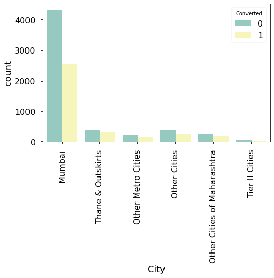

```python
# PLot the count plot to observe againts converted
# Function Info: plot_count_plot(dataframe,column,huge_column)
plot_count_plot(lead_score_df,'City','Converted')
```

```python
#checking value counts of Specialization column
value_count_dt(lead_score_df,'Specialization')
```

```
NaN                                  3380
Finance Management                    976
Human Resource Management             848
Marketing Management                  838
Operations Management                 503
Business Administration               403
IT Projects Management                366
Supply Chain Management               349
Banking, Investment And Insurance     338
Media and Advertising                 203
Travel and Tourism                    203
International Business                178
Healthcare Management                 159
Hospitality Management                114
E-COMMERCE                            112
Retail Management                     100
Rural and Agribusiness                 73
E-Business                             57
Services Excellence                    40
Name: Specialization, dtype: int64
```

```
    The leader may not have indicated specialization since it was not on the list, or they may be students without a specialization yet. So, we replace NaN values here with 'Not Specified'.
```

```python
lead_score_df['Specialization'] = lead_score_df['Specialization'].replace(np.nan,'Not Specified')
value_count_dt(lead_score_df,'Specialization')
```

```
Not Specified                        3380
Finance Management                    976
Human Resource Management             848
Marketing Management                  838
Operations Management                 503
Business Administration               403
IT Projects Management                366
Supply Chain Management               349
Banking, Investment And Insurance     338
Media and Advertising                 203
Travel and Tourism                    203
International Business                178
Healthcare Management                 159
Hospitality Management                114
E-COMMERCE                            112
Retail Management                     100
Rural and Agribusiness                 73
E-Business                             57
Services Excellence                    40
Name: Specialization, dtype: int64
```

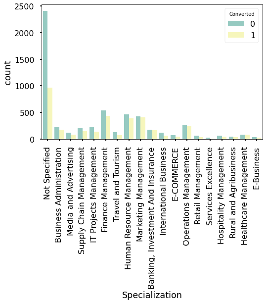

```python
# PLot the count plot to observe againts converted
# Function Info: plot_count_plot(dataframe,column,huge_column)
plot_count_plot(lead_score_df,'Specialization','Converted')
```

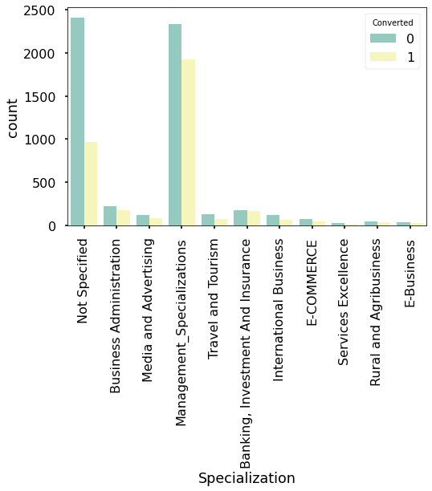

```python
# combining Management Specializations because they show similar trends

lead_score_df['Specialization'] = lead_score_df['Specialization'].replace(['Finance Management','Human Resource Management',
                                                           'Marketing Management','Operations Management',
                                                           'IT Projects Management','Supply Chain Management',
                                                    'Healthcare Management','Hospitality Management',
                                                           'Retail Management'] ,'Management_Specializations')
plot_count_plot(lead_score_df,'Specialization','Converted')
```

```python
#checking value counts of 'What is your current occupation' column

value_count_dt(lead_score_df,'What is your current occupation')
```

```
Unemployed              5600
NaN                     2690
Working Professional     706
Student                  210
Other                     16
Housewife                 10
Businessman                8
Name: What is your current occupation, dtype: int64
```

```python
# Replacing NAN with 'Unemployed'
lead_score_df['What is your current occupation'] = lead_score_df['What is your current occupation'].replace(np.nan,'Unemployed')
value_count_dt(lead_score_df,'What is your current occupation')
```

```
Unemployed              8290
Working Professional     706
Student                  210
Other                     16
Housewife                 10
Businessman                8
Name: What is your current occupation, dtype: int64
```

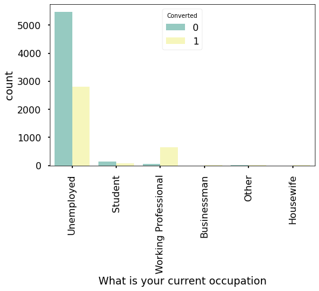

```python
# PLot the count plot to observe againts converted
# Function Info: plot_count_plot(dataframe,column,huge_column)
plot_count_plot(lead_score_df,'What is your current occupation','Converted')
```

```
    1) Working Professionals going for the course have high chances of joining it.
    2) More number of joining cource are in umemployed
```

```python
#checking value counts of 'What matters most to you in choosing a course' column

value_count_dt(lead_score_df,'What matters most to you in choosing a course')
```

```
Better Career Prospects      6528
NaN                          2709
Flexibility & Convenience       2
Other                           1
Name: What matters most to you in choosing a course, dtype: int64
```

```python
#replacing Nan values with Mode "Better Career Prospects"

lead_score_df['What matters most to you in choosing a course'] = lead_score_df['What matters most to you in choosing a course'].replace(np.nan,'Better Career Prospects')

value_count_dt(lead_score_df,'What matters most to you in choosing a course')
```

```
Better Career Prospects      9237
Flexibility & Convenience       2
Other                           1
Name: What matters most to you in choosing a course, dtype: int64
```

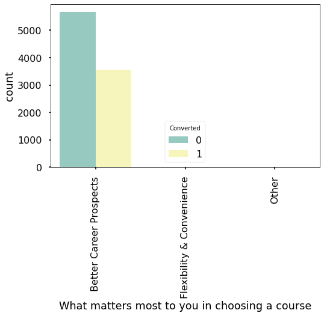

```python
# PLot the count plot to observe againts converted
# Function Info: plot_count_plot(dataframe,column,huge_column)
plot_count_plot(lead_score_df,'What matters most to you in choosing a course','Converted')
```

```python
#checking Better Career Prospects has more and it indicate to drop the coloumn

cols_to_drop.append('What matters most to you in choosing a course')
cols_to_drop
```

```
['Country', 'What matters most to you in choosing a course']
```

```python
#checking value counts of 'What matters most to you in choosing a course' column

value_count_dt(lead_score_df,'Tags')
```

```
NaN                                                  3353
Will revert after reading the email                  2072
Ringing                                              1203
Interested in other courses                           513
Already a student                                     465
Closed by Horizzon                                    358
switched off                                          240
Busy                                                  186
Lost to EINS                                          175
Not doing further education                           145
Interested  in full time MBA                          117
Graduation in progress                                111
invalid number                                         83
Diploma holder (Not Eligible)                          63
wrong number given                                     47
opp hangup                                             33
number not provided                                    27
in touch with EINS                                     12
Lost to Others                                          7
Still Thinking                                          6
Want to take admission but has financial problems       6
In confusion whether part time or DLP                   5
Interested in Next batch                                5
Lateral student                                         3
Shall take in the next coming month                     2
University not recognized                               2
Recognition issue (DEC approval)                        1
Name: Tags, dtype: int64
```

```python
#replacing Nan values with "Not Specified"
lead_score_df['Tags'] = lead_score_df['Tags'].replace(np.nan,'Not Specified')
value_count_dt(lead_score_df,'Tags')
```

```
Not Specified                                        3353
Will revert after reading the email                  2072
Ringing                                              1203
Interested in other courses                           513
Already a student                                     465
Closed by Horizzon                                    358
switched off                                          240
Busy                                                  186
Lost to EINS                                          175
Not doing further education                           145
Interested  in full time MBA                          117
Graduation in progress                                111
invalid number                                         83
Diploma holder (Not Eligible)                          63
wrong number given                                     47
opp hangup                                             33
number not provided                                    27
in touch with EINS                                     12
Lost to Others                                          7
Still Thinking                                          6
Want to take admission but has financial problems       6
In confusion whether part time or DLP                   5
Interested in Next batch                                5
Lateral student                                         3
Shall take in the next coming month                     2
University not recognized                               2
Recognition issue (DEC approval)                        1
Name: Tags, dtype: int64
```

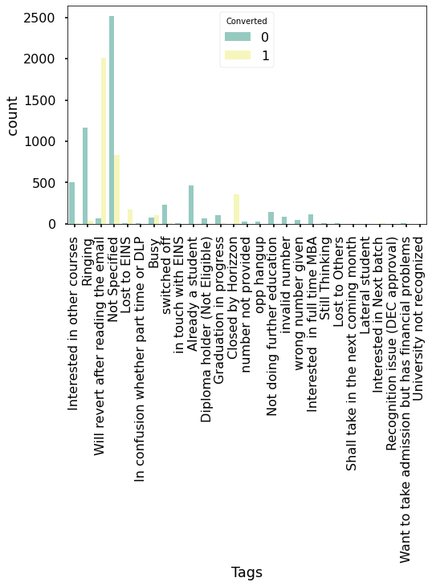

```python
# PLot the count plot to observe againts converted
# Function Info: plot_count_plot(dataframe,column,huge_column)
plot_count_plot(lead_score_df,'Tags','Converted')
```

```python
#replacing tags with low frequency with "Other Tags"
lead_score_df['Tags'] = lead_score_df['Tags'].replace(['In confusion whether part time or DLP', 'in touch with EINS','Diploma holder (Not Eligible)',
                                     'Approached upfront','Graduation in progress','number not provided', 'opp hangup','Still Thinking',
                                    'Lost to Others','Shall take in the next coming month','Lateral student','Interested in Next batch',
                                    'Recognition issue (DEC approval)','Want to take admission but has financial problems',
                                    'University not recognized'], 'Other_Tags')

lead_score_df['Tags'] = lead_score_df['Tags'].replace(['switched off',
                                      'Already a student',
                                       'Not doing further education',
                                       'invalid number',
                                       'wrong number given',
                                       'Interested  in full time MBA'] , 'Other_Tags')
```

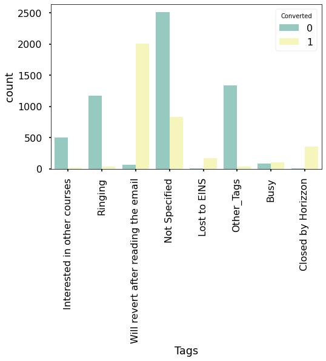

```python
# PLot the count plot to observe againts converted
# Function Info: plot_count_plot(dataframe,column,huge_column)
plot_count_plot(lead_score_df,'Tags','Converted')
```

```python
#checking percentage of missing values
round(100*(lead_score_df.isnull().sum()/len(lead_score_df.index)), 2).sort_values(ascending=False)
```

```
TotalVisits                                      1.48
Page Views Per Visit                             1.48
Last Activity                                    1.11
Lead Source                                      0.39
Lead Origin                                      0.00
X Education Forums                               0.00
A free copy of Mastering The Interview           0.00
I agree to pay the amount through cheque         0.00
City                                             0.00
Get updates on DM Content                        0.00
Update me on Supply Chain Content                0.00
Tags                                             0.00
Receive More Updates About Our Courses           0.00
Through Recommendations                          0.00
Digital Advertisement                            0.00
Newspaper                                        0.00
Magazine                                         0.00
Newspaper Article                                0.00
Search                                           0.00
What matters most to you in choosing a course    0.00
What is your current occupation                  0.00
Specialization                                   0.00
Country                                          0.00
Total Time Spent on Website                      0.00
Converted                                        0.00
Do Not Call                                      0.00
Do Not Email                                     0.00
Last Notable Activity                            0.00
dtype: float64
```

```python
# Checking the value for 'Lead Source' Column
value_count_dt(lead_score_df,'Lead Source')
```

```
Google               2868
Direct Traffic       2543
Olark Chat           1755
Organic Search       1154
Reference             534
Welingak Website      142
Referral Sites        125
Facebook               55
NaN                    36
bing                    6
google                  5
Click2call              4
Press_Release           2
Social Media            2
Live Chat               2
youtubechannel          1
testone                 1
Pay per Click Ads       1
welearnblog_Home        1
WeLearn                 1
blog                    1
NC_EDM                  1
Name: Lead Source, dtype: int64
```

```python
# Replcaing NAN with 'Others' and grouping low frequency into Others as well
lead_score_df['Lead Source'] = lead_score_df['Lead Source'].replace(np.nan,'Others')
lead_score_df['Lead Source'] = lead_score_df['Lead Source'].replace(['bing','Click2call','Press_Release',
                                                     'youtubechannel','welearnblog_Home',
                                                     'WeLearn','blog','Pay per Click Ads',
                                                    'testone','NC_EDM'] ,'Others')
value_count_dt(lead_score_df,'Lead Source')
```

```
Google              2868
Direct Traffic      2543
Olark Chat          1755
Organic Search      1154
Reference            534
Welingak Website     142
Referral Sites       125
Facebook              55
Others                55
google                 5
Social Media           2
Live Chat              2
Name: Lead Source, dtype: int64
```

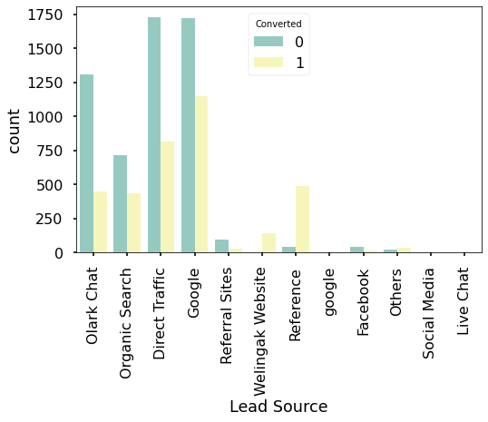

```python
# PLot the count plot to observe againts converted
# Function Info: plot_count_plot(dataframe,column,huge_column)
plot_count_plot(lead_score_df,'Lead Source','Converted')
```

```
    1) Max number of lead from Google link and followed by Direct traffic
    2) most conversion of leads from the welingak website
    3) Improve the conversion rate, Need to focus on the olark chat, Organic Search, Direct traffic and google search
```

```python
# Checking the value for 'Last Activity' Column
value_count_dt(lead_score_df,'Last Activity')
```

```
Email Opened                    3437
SMS Sent                        2745
Olark Chat Conversation          973
Page Visited on Website          640
Converted to Lead                428
Email Bounced                    326
Email Link Clicked               267
Form Submitted on Website        116
NaN                              103
Unreachable                       93
Unsubscribed                      61
Had a Phone Conversation          30
Approached upfront                 9
View in browser link Clicked       6
Email Received                     2
Email Marked Spam                  2
Visited Booth in Tradeshow         1
Resubscribed to emails             1
Name: Last Activity, dtype: int64
```

```python
#replacing Nan Values and combining low frequency values

lead_score_df['Last Activity'] = lead_score_df['Last Activity'].replace(np.nan,'Others')
lead_score_df['Last Activity'] = lead_score_df['Last Activity'].replace(['Unreachable','Unsubscribed',
                                                        'Had a Phone Conversation',
                                                        'Approached upfront',
                                                        'View in browser link Clicked',
                                                        'Email Marked Spam',
                                                        'Email Received','Resubscribed to emails',
                                                         'Visited Booth in Tradeshow'],'Others')
value_count_dt(lead_score_df,'Last Activity')
```

```
Email Opened                 3437
SMS Sent                     2745
Olark Chat Conversation       973
Page Visited on Website       640
Converted to Lead             428
Email Bounced                 326
Others                        308
Email Link Clicked            267
Form Submitted on Website     116
Name: Last Activity, dtype: int64
```

[figure not shown]

```python
# PLot the count plot to observe againts converted
# Function Info: plot_count_plot(dataframe,column,huge_column)
plot_count_plot(lead_score_df,'Last Activity','Converted')
```

```python
#Now, we are check the Null Values in All Columns:
round(100*(lead_score_df.isnull().sum()/len(lead_score_df.index)), 2).sort_values(ascending=False)
```

```
TotalVisits                                      1.48
Page Views Per Visit                             1.48
Lead Origin                                      0.00
Newspaper Article                                0.00
A free copy of Mastering The Interview           0.00
I agree to pay the amount through cheque         0.00
City                                             0.00
Get updates on DM Content                        0.00
Update me on Supply Chain Content                0.00
Tags                                             0.00
Receive More Updates About Our Courses           0.00
Through Recommendations                          0.00
Digital Advertisement                            0.00
Newspaper                                        0.00
X Education Forums                               0.00
Magazine                                         0.00
Lead Source                                      0.00
Search                                           0.00
What matters most to you in choosing a course    0.00
What is your current occupation                  0.00
Specialization                                   0.00
Country                                          0.00
Last Activity                                    0.00
Total Time Spent on Website                      0.00
Converted                                        0.00
Do Not Call                                      0.00
Do Not Email                                     0.00
Last Notable Activity                            0.00
dtype: float64
```

```
Drop all rows which have Nan Values. Since the number of Dropped rows is less than 2%, it will not affect the model
```

```python
lead_score_df.dropna(inplace=True)
```

```python
round(100*(lead_score_df.isnull().sum()/len(lead_score_df.index)), 2).sort_values(ascending=False)
```

```
Lead Origin                                      0.0
Lead Source                                      0.0
A free copy of Mastering The Interview           0.0
I agree to pay the amount through cheque         0.0
City                                             0.0
Get updates on DM Content                        0.0
Update me on Supply Chain Content                0.0
Tags                                             0.0
Receive More Updates About Our Courses           0.0
Through Recommendations                          0.0
Digital Advertisement                            0.0
Newspaper                                        0.0
X Education Forums                               0.0
Newspaper Article                                0.0
Magazine                                         0.0
Search                                           0.0
What matters most to you in choosing a course    0.0
What is your current occupation                  0.0
Specialization                                   0.0
Country                                          0.0
Last Activity                                    0.0
Page Views Per Visit                             0.0
Total Time Spent on Website                      0.0
TotalVisits                                      0.0
Converted                                        0.0
Do Not Call                                      0.0
Do Not Email                                     0.0
Last Notable Activity                            0.0
dtype: float64
```

```python
# Checking the value for 'Lead Origin' Column
value_count_dt(lead_score_df,'Lead Origin')
```

```
Landing Page Submission    4886
API                        3578
Lead Add Form               608
Lead Import                  31
Name: Lead Origin, dtype: int64
```

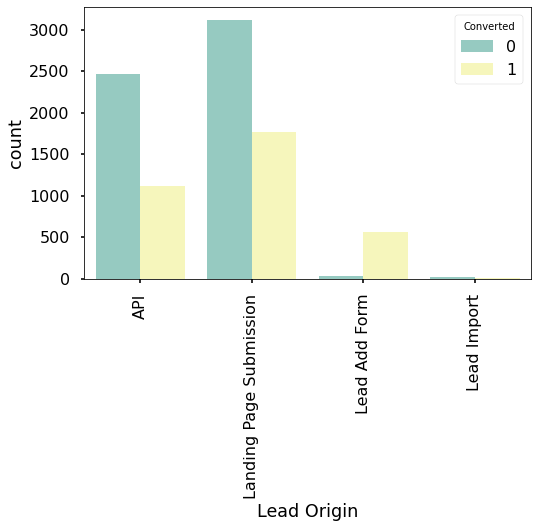

```python
# PLot the count plot to observe againts converted
# Function Info: plot_count_plot(dataframe,column,huge_column)
plot_count_plot(lead_score_df,'Lead Origin','Converted')
```

```
API and Landing Page Submission bring higher number of leads as well as conversion.
Lead Add Form has a very high conversion rate but count of leads are not very high.
Lead Import and Quick Add Form get very few leads.
```

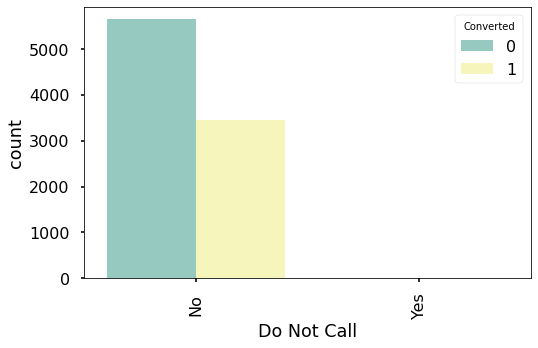

```python
# checking the Do Not Call values
plot_count_plot(lead_score_df,'Do Not Call','Converted')
```

```
    Do Not Call coloum has more than 95 % single value. It will be drop for prediction
```

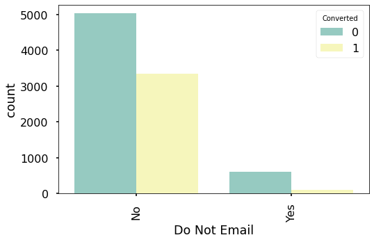

```python
# checking the Do Not Email column
plot_count_plot(lead_score_df,'Do Not Email','Converted')
```

```python
cols_to_drop.append('Do Not Call')
cols_to_drop
```

```
['Country', 'What matters most to you in choosing a course', 'Do Not Call']
```

```python
# Checking the value for 'Last Notable Activity' Column
value_count_dt(lead_score_df,'Last Notable Activity')
```

```
Modified                        3270
Email Opened                    2827
SMS Sent                        2172
Page Visited on Website          318
Olark Chat Conversation          183
Email Link Clicked               173
Email Bounced                     60
Unsubscribed                      47
Unreachable                       32
Had a Phone Conversation          14
Email Marked Spam                  2
Approached upfront                 1
Resubscribed to emails             1
View in browser link Clicked       1
Form Submitted on Website          1
Email Received                     1
Name: Last Notable Activity, dtype: int64
```

```python
#clubbing lower frequency values

lead_score_df['Last Notable Activity'] = lead_score_df['Last Notable Activity'].replace(['Had a Phone Conversation',
                                                                       'Email Marked Spam',
                                                                         'Unreachable',
                                                                         'Unsubscribed',
                                                                         'Email Bounced',
                                                                       'Resubscribed to emails',
                                                                       'View in browser link Clicked',
                                                                       'Approached upfront',
                                                                       'Form Submitted on Website',
                                                                       'Email Received'],'Other_Notable_activity')
```

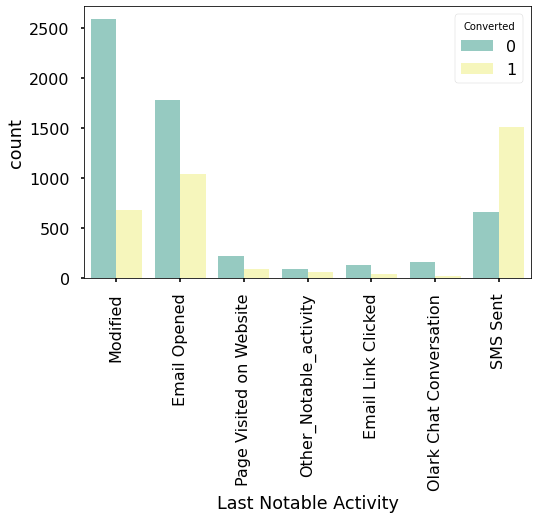

```python
# PLot the count plot to observe againts converted
# Function Info: plot_count_plot(dataframe,column,huge_column)
plot_count_plot(lead_score_df,'Last Notable Activity','Converted')
```

```python
# Checking the value for 'Search','Magazine', 'Newspaper Article', 'X Education Forums' Column
remaining_column_for_anyz = ['Search','Magazine','Newspaper Article','X Education Forums','Newspaper','Digital Advertisement',
                            'Through Recommendations','Receive More Updates About Our Courses','Update me on Supply Chain Content',
                             'Get updates on DM Content','I agree to pay the amount through cheque','A free copy of Mastering The Interview'
                            ]

for column in remaining_column_for_anyz:
    print(column ," colum : \n",value_count_dt(lead_score_df, column ))
    print("\n\n")
```

```
Search  colum :
 No     9089
Yes      14
Name: Search, dtype: int64



Magazine  colum :
 No    9103
Name: Magazine, dtype: int64



Newspaper Article  colum :
 No     9101
Yes       2
Name: Newspaper Article, dtype: int64



X Education Forums  colum :
 No     9102
Yes       1
Name: X Education Forums, dtype: int64



Newspaper  colum :
 No     9102
Yes       1
Name: Newspaper, dtype: int64



Digital Advertisement  colum :
 No     9099
Yes       4
Name: Digital Advertisement, dtype: int64


```

[output cut: 21 more lines]

```
 No    9103
Name: Get updates on DM Content, dtype: int64



I agree to pay the amount through cheque  colum :
 No    9103
Name: I agree to pay the amount through cheque, dtype: int64



A free copy of Mastering The Interview  colum :
 No     6215
Yes    2888
Name: A free copy of Mastering The Interview, dtype: int64
```

```
As we observe above , all the column show it imbalance other than 'A free copy of Mastering The Interview' , so we will drop these column expect 'A free copy of Mastering The Interview'
```

```python
remaining_column_for_anyz.remove('A free copy of Mastering The Interview')
cols_to_drop.extend(remaining_column_for_anyz)
cols_to_drop
```

```
['Country',
 'What matters most to you in choosing a course',
 'Do Not Call',
 'Search',
 'Magazine',
 'Newspaper Article',
 'X Education Forums',
 'Newspaper',
 'Digital Advertisement',
 'Through Recommendations',
 'Receive More Updates About Our Courses',
 'Update me on Supply Chain Content',
 'Get updates on DM Content',
 'I agree to pay the amount through cheque']
```

```python
lead_score_df.drop(cols_to_drop,1,inplace=True)
lead_score_df.info()
```

```
<class 'pandas.core.frame.DataFrame'>
Int64Index: 9103 entries, 0 to 9239
Data columns (total 14 columns):
 #   Column                                  Non-Null Count  Dtype
---  ------                                  --------------  -----
 0   Lead Origin                             9103 non-null   object
 1   Lead Source                             9103 non-null   object
 2   Do Not Email                            9103 non-null   object
 3   Converted                               9103 non-null   int64
 4   TotalVisits                             9103 non-null   float64
 5   Total Time Spent on Website             9103 non-null   int64
 6   Page Views Per Visit                    9103 non-null   float64
 7   Last Activity                           9103 non-null   object
 8   Specialization                          9103 non-null   object
 9   What is your current occupation         9103 non-null   object
 10  Tags                                    9103 non-null   object
 11  City                                    9103 non-null   object
 12  A free copy of Mastering The Interview  9103 non-null   object
 13  Last Notable Activity                   9103 non-null   object
dtypes: float64(2), int64(2), object(10)
memory usage: 1.0+ MB
```

#### Correlation and number analysis of Leads

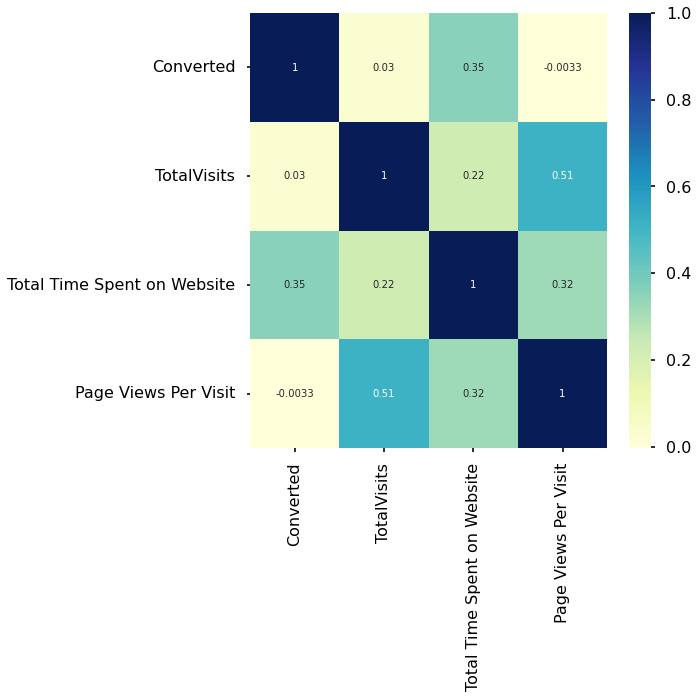

```python
#Checking correlations of numeric values
# figure size
plt.figure(figsize=(8,8))

# heatmap
sns.heatmap(lead_score_df.corr(), cmap="YlGnBu", annot=True)
plt.show()
```

```python
def box_plot(dataframe_column_value,x_axis=None,data=None):
    # dataframe_column_value params: either coloum values or colum Name(when _axis Passed)
    plt.figure(figsize=(6,4))
    if x_axis != None:
        sns.boxplot(x=x_axis,y=dataframe_column_value,data=data)
    else:
        sns.boxplot(y=dataframe_column_value)
    plt.show()
```

```python
def find_percentile(dataframe,column):
    return dataframe[column].describe(percentiles=[0.05,.25, .5, .75, .90, .95, .99])

def treat_outliers(dataframe,column,top_treat,bottom_treat):
    Q3 = dataframe[column].quantile(top_treat)
    dataframe = dataframe[(dataframe[column] <= Q3)]
    Q1 = dataframe[column].quantile(bottom_treat)
    dataframe = dataframe[(dataframe[column] >= Q1)]
    box_plot(dataframe[column])
    return dataframe
```

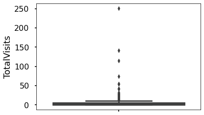

```python
#Total Visits
#visualizing spread of variable
box_plot(lead_score_df['TotalVisits'])
```

```python
find_percentile(lead_score_df,'TotalVisits')
```

```
count    9103.000000
mean        3.445238
std         4.854853
min         0.000000
5%          0.000000
25%         1.000000
50%         3.000000
75%         5.000000
90%         7.000000
95%        10.000000
99%        17.000000
max       251.000000
Name: TotalVisits, dtype: float64
```

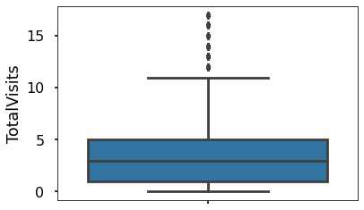

```python
#Outlier Treatment: Remove top & bottom 1% of the Column Outlier values
# Function params: treat_outliers(dataframe,column,top_treat,bottom_treat):
lead_score_df = treat_outliers(lead_score_df,'TotalVisits',0.99,0.01)
```

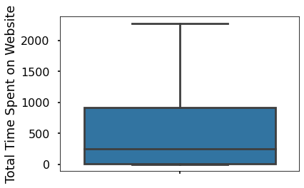

```python
#visualizing spread of numeric variable
box_plot(lead_score_df['Total Time Spent on Website'])
```

```
        1) This column has no outlier. so we don't ned to treat it
```

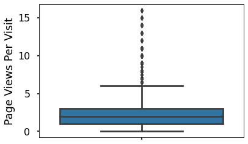

```python
#checking spread of "Page Views Per Visit"
#visualizing spread of variable
box_plot(lead_score_df['Page Views Per Visit'])
```

```python
# 'Page Views Per Visit' column has outlier we need to treat the outlier
# we will find the percentile so, we can treat

find_percentile(lead_score_df,'Page Views Per Visit')
```

```
count    9020.000000
mean        2.337271
std         2.062363
min         0.000000
5%          0.000000
25%         1.000000
50%         2.000000
75%         3.000000
90%         5.000000
95%         6.000000
99%         9.000000
max        16.000000
Name: Page Views Per Visit, dtype: float64
```

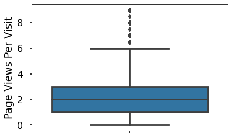

```python
# we will apply top and bottom 1% to treat the outlier
lead_score_df = treat_outliers(lead_score_df,'Page Views Per Visit',0.99,0.01)
```

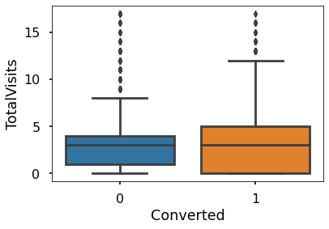

```python
#checking Spread of "Total Visits" vs Converted variable
box_plot('TotalVisits','Converted',lead_score_df)
```

```
    Onservation:
         Median of both converted vs non converted for Total visits are very close
```

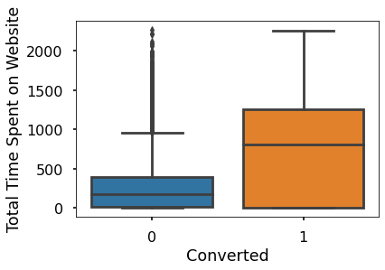

```python
# checking the relation between 'Total Time Spent on Website' and 'converted'
box_plot('Total Time Spent on Website','Converted',lead_score_df)
```

```
1) Leads that spend more time on the website are more likely to convert.
2) To encourage leads to spend more time on the website, it should be more interesting.
```

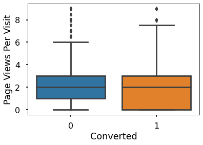

```python
#checking Spread of "Page Views Per Visit" vs Converted column
box_plot('Page Views Per Visit','Converted',lead_score_df)
```

```
1) The median for converted and unconverted leads is the same.
```

```python
# Checking the null value before creating dummy variables
round(100*(lead_score_df.isnull().sum()/len(lead_score_df.index)),2)
```

```
Lead Origin                               0.0
Lead Source                               0.0
Do Not Email                              0.0
Converted                                 0.0
TotalVisits                               0.0
Total Time Spent on Website               0.0
Page Views Per Visit                      0.0
Last Activity                             0.0
Specialization                            0.0
What is your current occupation           0.0
Tags                                      0.0
City                                      0.0
A free copy of Mastering The Interview    0.0
Last Notable Activity                     0.0
dtype: float64
```

```python
cat_cols= lead_score_df.select_dtypes(include=['object']).columns
cat_cols
```

```
Index(['Lead Origin', 'Lead Source', 'Do Not Email', 'Last Activity',
       'Specialization', 'What is your current occupation', 'Tags', 'City',
       'A free copy of Mastering The Interview', 'Last Notable Activity'],
      dtype='object')
```

#### Creating Dummy Variables:

```python
# List of variables to map

variable_list =  ['A free copy of Mastering The Interview','Do Not Email']

# Defining the map function
def binary_map(x):
    return x.map({'Yes': 1, "No": 0})

lead_score_df[variable_list] = lead_score_df[variable_list].apply(binary_map)
```

```python
lead_score_df[variable_list]
```

|  | A free copy of Mastering The Interview | Do Not Email |
| --- | --- | --- |
| 0 | 0 | 0 |
| 1 | 0 | 0 |
| 2 | 1 | 0 |
| 3 | 0 | 0 |
| 4 | 0 | 0 |
| ... | ... | ... |
| 9235 | 0 | 1 |
| 9236 | 1 | 0 |
| 9237 | 1 | 1 |
| 9238 | 0 | 0 |
| 9239 | 1 | 0 |

8953 rows × 2 columns

```python
#getting dummies and dropping the first column and adding the results to the master dataframe
dummy = pd.get_dummies(lead_score_df[['Lead Origin','What is your current occupation',
                             'City']], drop_first=True)

lead_score_df = pd.concat([lead_score_df,dummy],1)
lead_score_df.head()
```

|  | Lead Origin | Lead Source | Do Not Email | Converted | TotalVisits | Total Time Spent on Website | Page Views Per Visit | Last Activity | Specialization | What is your current occupation | ... | What is your current occupation_Housewife | What is your current occupation_Other | What is your current occupation_Student | What is your current occupation_Unemployed | What is your current occupation_Working Professional | City_Other Cities | City_Other Cities of Maharashtra | City_Other Metro Cities | City_Thane & Outskirts | City_Tier II Cities |
| --- | --- | --- | --- | --- | --- | --- | --- | --- | --- | --- | --- | --- | --- | --- | --- | --- | --- | --- | --- | --- | --- |
| 0 | API | Olark Chat | 0 | 0 | 0.0 | 0 | 0.0 | Page Visited on Website | Not Specified | Unemployed | ... | 0 | 0 | 0 | 1 | 0 | 0 | 0 | 0 | 0 | 0 |
| 1 | API | Organic Search | 0 | 0 | 5.0 | 674 | 2.5 | Email Opened | Not Specified | Unemployed | ... | 0 | 0 | 0 | 1 | 0 | 0 | 0 | 0 | 0 | 0 |
| 2 | Landing Page Submission | Direct Traffic | 0 | 1 | 2.0 | 1532 | 2.0 | Email Opened | Business Administration | Student | ... | 0 | 0 | 1 | 0 | 0 | 0 | 0 | 0 | 0 | 0 |
| 3 | Landing Page Submission | Direct Traffic | 0 | 0 | 1.0 | 305 | 1.0 | Others | Media and Advertising | Unemployed | ... | 0 | 0 | 0 | 1 | 0 | 0 | 0 | 0 | 0 | 0 |
| 4 | Landing Page Submission | Google | 0 | 1 | 2.0 | 1428 | 1.0 | Converted to Lead | Not Specified | Unemployed | ... | 0 | 0 | 0 | 1 | 0 | 0 | 0 | 0 | 0 | 0 |

5 rows × 27 columns

```python
dummy = pd.get_dummies(lead_score_df['Specialization'], prefix  = 'Specialization')
dummy = dummy.drop(['Specialization_Not Specified'], 1)
lead_score_df = pd.concat([lead_score_df, dummy], axis = 1)
lead_score_df.shape
```

```
(8953, 37)
```

```python
dummy = pd.get_dummies(lead_score_df['Lead Source'], prefix  = 'Lead Source')
dummy = dummy.drop(['Lead Source_Others'], 1)
lead_score_df = pd.concat([lead_score_df, dummy], axis = 1)
lead_score_df.shape
```

```
(8953, 48)
```

```python
dummy = pd.get_dummies(lead_score_df['Last Activity'], prefix  = 'Last Activity')
dummy = dummy.drop(['Last Activity_Others'], 1)
lead_score_df = pd.concat([lead_score_df, dummy], axis = 1)
lead_score_df.shape
```

```
(8953, 56)
```

```python
dummy = pd.get_dummies(lead_score_df['Last Notable Activity'], prefix  = 'Last Notable Activity')
dummy = dummy.drop(['Last Notable Activity_Other_Notable_activity'], 1)
lead_score_df = pd.concat([lead_score_df, dummy], axis = 1)
lead_score_df.shape
```

```
(8953, 62)
```

```python
dummy = pd.get_dummies(lead_score_df['Tags'], prefix  = 'Tags')
dummy = dummy.drop(['Tags_Not Specified'], 1)
lead_score_df = pd.concat([lead_score_df, dummy], axis = 1)
lead_score_df.shape
```

```
(8953, 69)
```

```python
lead_score_df.drop(cat_cols,1,inplace = True)
lead_score_df.shape
```

```
(8953, 59)
```

```python
lead_score_df.info('all')
```

```
<class 'pandas.core.frame.DataFrame'>
Int64Index: 8953 entries, 0 to 9239
Data columns (total 59 columns):
 #   Column                                                Non-Null Count  Dtype
---  ------                                                --------------  -----
 0   Converted                                             8953 non-null   int64
 1   TotalVisits                                           8953 non-null   float64
 2   Total Time Spent on Website                           8953 non-null   int64
 3   Page Views Per Visit                                  8953 non-null   float64
 4   Lead Origin_Landing Page Submission                   8953 non-null   uint8
 5   Lead Origin_Lead Add Form                             8953 non-null   uint8
 6   Lead Origin_Lead Import                               8953 non-null   uint8
 7   What is your current occupation_Housewife             8953 non-null   uint8
 8   What is your current occupation_Other                 8953 non-null   uint8
 9   What is your current occupation_Student               8953 non-null   uint8
```

[output cut: 51 more lines]

```python
lead_score_df.head(3)
```

|  | Converted | TotalVisits | Total Time Spent on Website | Page Views Per Visit | Lead Origin_Landing Page Submission | Lead Origin_Lead Add Form | Lead Origin_Lead Import | What is your current occupation_Housewife | What is your current occupation_Other | What is your current occupation_Student | ... | Last Notable Activity_Olark Chat Conversation | Last Notable Activity_Page Visited on Website | Last Notable Activity_SMS Sent | Tags_Busy | Tags_Closed by Horizzon | Tags_Interested in other courses | Tags_Lost to EINS | Tags_Other_Tags | Tags_Ringing | Tags_Will revert after reading the email |
| --- | --- | --- | --- | --- | --- | --- | --- | --- | --- | --- | --- | --- | --- | --- | --- | --- | --- | --- | --- | --- | --- |
| 0 | 0 | 0.0 | 0 | 0.0 | 0 | 0 | 0 | 0 | 0 | 0 | ... | 0 | 0 | 0 | 0 | 0 | 1 | 0 | 0 | 0 | 0 |
| 1 | 0 | 5.0 | 674 | 2.5 | 0 | 0 | 0 | 0 | 0 | 0 | ... | 0 | 0 | 0 | 0 | 0 | 0 | 0 | 0 | 1 | 0 |
| 2 | 1 | 2.0 | 1532 | 2.0 | 1 | 0 | 0 | 0 | 0 | 1 | ... | 0 | 0 | 0 | 0 | 0 | 0 | 0 | 0 | 0 | 1 |

3 rows × 59 columns

#### Spliting Train and Test from the lead_score_df

```python
from sklearn.model_selection import train_test_split
X = lead_score_df.drop('Converted', axis=1)
y = lead_score_df['Converted']
```

```python
# Splitting the data into train and test
X_train, X_test, y_train, y_test = train_test_split(X, y, train_size=0.7, test_size=0.3, random_state=112)
```

```python
#scaling numeric columns

from sklearn.preprocessing import StandardScaler

scaler = StandardScaler()

num_cols=X_train.select_dtypes(include=['float64', 'int64']).columns

X_train[num_cols] = scaler.fit_transform(X_train[num_cols])

X_train.head()
```

|  | TotalVisits | Total Time Spent on Website | Page Views Per Visit | Lead Origin_Landing Page Submission | Lead Origin_Lead Add Form | Lead Origin_Lead Import | What is your current occupation_Housewife | What is your current occupation_Other | What is your current occupation_Student | What is your current occupation_Unemployed | ... | Last Notable Activity_Olark Chat Conversation | Last Notable Activity_Page Visited on Website | Last Notable Activity_SMS Sent | Tags_Busy | Tags_Closed by Horizzon | Tags_Interested in other courses | Tags_Lost to EINS | Tags_Other_Tags | Tags_Ringing | Tags_Will revert after reading the email |
| --- | --- | --- | --- | --- | --- | --- | --- | --- | --- | --- | --- | --- | --- | --- | --- | --- | --- | --- | --- | --- | --- |
| 664 | -0.053019 | -0.614345 | 0.386111 | 0 | 0 | 0 | 0 | 0 | 0 | 1 | ... | 0 | 0 | 0 | 0 | 0 | 0 | 0 | 0 | 0 | 0 |
| 2967 | 0.291658 | -0.214580 | 0.914368 | 1 | 0 | 0 | 0 | 0 | 0 | 1 | ... | 0 | 0 | 0 | 0 | 0 | 0 | 0 | 0 | 0 | 1 |
| 6449 | 1.670363 | -0.104552 | -0.353450 | 1 | 0 | 0 | 0 | 0 | 0 | 1 | ... | 0 | 0 | 1 | 0 | 0 | 0 | 0 | 0 | 0 | 1 |
| 7177 | -0.397695 | 0.656470 | -0.670404 | 0 | 0 | 0 | 0 | 0 | 0 | 1 | ... | 0 | 0 | 1 | 0 | 0 | 0 | 0 | 0 | 0 | 0 |
| 2189 | 0.636334 | 0.478592 | 0.121982 | 1 | 0 | 0 | 0 | 0 | 0 | 1 | ... | 0 | 1 | 0 | 0 | 0 | 0 | 0 | 0 | 0 | 1 |

5 rows × 58 columns

#### Model Building using Stats Model & RFE:

```python
# Importing RFE and LinearRegression
from sklearn.feature_selection import RFE
from sklearn.linear_model import LogisticRegression
import statsmodels.api as sm
from statsmodels.stats.outliers_influence import variance_inflation_factor
from sklearn.metrics import mean_squared_error
from sklearn.metrics import r2_score
from sklearn import metrics
from sklearn.metrics import confusion_matrix, ConfusionMatrixDisplay
from sklearn.metrics import precision_score, recall_score
from sklearn.metrics import classification_report
```

```python
lr_model = LogisticRegression()

rfe = RFE(lr_model,n_features_to_select=15,step=1)             # running RFE with 15 variables as output
rfe = rfe.fit(X_train, y_train)
```

```python
list(zip(X_train.columns, rfe.support_, rfe.ranking_))
```

```
[('TotalVisits', False, 26),
 ('Total Time Spent on Website', True, 1),
 ('Page Views Per Visit', False, 25),
 ('Lead Origin_Landing Page Submission', False, 6),
 ('Lead Origin_Lead Add Form', True, 1),
 ('Lead Origin_Lead Import', False, 23),
 ('What is your current occupation_Housewife', False, 32),
 ('What is your current occupation_Other', False, 31),
 ('What is your current occupation_Student', False, 20),
 ('What is your current occupation_Unemployed', False, 19),
 ('What is your current occupation_Working Professional', False, 5),
 ('City_Other Cities', False, 33),
 ('City_Other Cities of Maharashtra', False, 36),
 ('City_Other Metro Cities', False, 11),
 ('City_Thane & Outskirts', False, 40),
 ('City_Tier II Cities', False, 41),
 ('Specialization_Banking, Investment And Insurance', False, 39),
 ('Specialization_Business Administration', False, 27),
 ('Specialization_E-Business', False, 42),
 ('Specialization_E-COMMERCE', False, 22),
 ('Specialization_International Business', False, 37),
 ('Specialization_Management_Specializations', False, 43),
 ('Specialization_Media and Advertising', False, 24),
 ('Specialization_Rural and Agribusiness', False, 18),
 ('Specialization_Services Excellence', False, 12),
 ('Specialization_Travel and Tourism', False, 4),
 ('Lead Source_Direct Traffic', False, 13),
 ('Lead Source_Facebook', False, 21),
 ('Lead Source_Google', False, 15),
 ('Lead Source_Live Chat', False, 44),
 ('Lead Source_Olark Chat', True, 1),
 ('Lead Source_Organic Search', False, 16),
 ('Lead Source_Reference', False, 7),
 ('Lead Source_Referral Sites', False, 14),
 ('Lead Source_Social Media', False, 38),
 ('Lead Source_Welingak Website', True, 1),
 ('Lead Source_google', False, 17),
 ('Last Activity_Converted to Lead', False, 8),
 ('Last Activity_Email Bounced', True, 1),
 ('Last Activity_Email Link Clicked', False, 29),
 ('Last Activity_Email Opened', False, 28),
 ('Last Activity_Form Submitted on Website', False, 30),
 ('Last Activity_Olark Chat Conversation', True, 1),
 ('Last Activity_Page Visited on Website', False, 9),
 ('Last Activity_SMS Sent', True, 1),
 ('Last Notable Activity_Email Link Clicked', False, 2),
 ('Last Notable Activity_Email Opened', False, 35),
 ('Last Notable Activity_Modified', True, 1),
 ('Last Notable Activity_Olark Chat Conversation', False, 10),
 ('Last Notable Activity_Page Visited on Website', False, 34),
 ('Last Notable Activity_SMS Sent', True, 1),
 ('Tags_Busy', False, 3),
 ('Tags_Closed by Horizzon', True, 1),
 ('Tags_Interested in other courses', True, 1),
 ('Tags_Lost to EINS', True, 1),
 ('Tags_Other_Tags', True, 1),
 ('Tags_Ringing', True, 1),
 ('Tags_Will revert after reading the email', True, 1)]
```

```python
#list of RFE supported columns
col = X_train.columns[rfe.support_]
col
```

```
Index(['Total Time Spent on Website', 'Lead Origin_Lead Add Form',
       'Lead Source_Olark Chat', 'Lead Source_Welingak Website',
       'Last Activity_Email Bounced', 'Last Activity_Olark Chat Conversation',
       'Last Activity_SMS Sent', 'Last Notable Activity_Modified',
       'Last Notable Activity_SMS Sent', 'Tags_Closed by Horizzon',
       'Tags_Interested in other courses', 'Tags_Lost to EINS',
       'Tags_Other_Tags', 'Tags_Ringing',
       'Tags_Will revert after reading the email'],
      dtype='object')
```

```python
# Calculate the VIFs for the new model
def calculate_VIF(col,X_train):
    vif = pd.DataFrame()
    vif['Features'] = col
    vif['VIF'] = [variance_inflation_factor(X_train[col].values, i) for i in range(X_train[col].shape[1])]
    vif['VIF'] = round(vif['VIF'], 2)
    vif = vif.sort_values(by = "VIF", ascending = False)
    display(vif)
```

```python
#BUILDING MODEL 1

X_train_sm = sm.add_constant(X_train[col])
logm1 = sm.GLM(y_train,X_train_sm, family = sm.families.Binomial())
res = logm1.fit()
res.summary()
```

Generalized Linear Model Regression Results

| Dep. Variable: | Converted | No. Observations: | 6267 |
| --- | --- | --- | --- |
| Model: | GLM | Df Residuals: | 6251 |
| Model Family: | Binomial | Df Model: | 15 |
| Link Function: | Logit | Scale: | 1.0000 |
| Method: | IRLS | Log-Likelihood: | -1218.4 |
| Date: | Sun, 10 Mar 2024 | Deviance: | 2436.9 |
| Time: | 19:02:29 | Pearson chi2: | 7.52e+03 |
| No. Iterations: | 24 | Pseudo R-squ. (CS): | 0.6094 |
| Covariance Type: | nonrobust |  |  |

|  | coef | std err | z | P>\|z\| | [0.025 | 0.975] |
| --- | --- | --- | --- | --- | --- | --- |
| const | -1.7500 | 0.099 | -17.737 | 0.000 | -1.943 | -1.557 |
| Total Time Spent on Website | 1.0731 | 0.061 | 17.649 | 0.000 | 0.954 | 1.192 |
| Lead Origin_Lead Add Form | 2.4770 | 0.435 | 5.695 | 0.000 | 1.624 | 3.329 |
| Lead Source_Olark Chat | 1.3699 | 0.151 | 9.102 | 0.000 | 1.075 | 1.665 |
| Lead Source_Welingak Website | 3.7901 | 1.109 | 3.418 | 0.001 | 1.617 | 5.963 |
| Last Activity_Email Bounced | -1.6110 | 0.505 | -3.192 | 0.001 | -2.600 | -0.622 |
| Last Activity_Olark Chat Conversation | -1.1029 | 0.243 | -4.532 | 0.000 | -1.580 | -0.626 |
| Last Activity_SMS Sent | 0.8511 | 0.238 | 3.569 | 0.000 | 0.384 | 1.318 |
| Last Notable Activity_Modified | -0.9721 | 0.162 | -5.986 | 0.000 | -1.290 | -0.654 |
| Last Notable Activity_SMS Sent | 1.5331 | 0.270 | 5.672 | 0.000 | 1.003 | 2.063 |
| Tags_Closed by Horizzon | 26.9884 | 1.37e+04 | 0.002 | 0.998 | -2.68e+04 | 2.69e+04 |
| Tags_Interested in other courses | -1.7768 | 0.355 | -5.009 | 0.000 | -2.472 | -1.082 |
| Tags_Lost to EINS | 5.4287 | 0.607 | 8.947 | 0.000 | 4.239 | 6.618 |
| Tags_Other_Tags | -2.4868 | 0.214 | -11.646 | 0.000 | -2.905 | -2.068 |
| Tags_Ringing | -3.6142 | 0.249 | -14.541 | 0.000 | -4.101 | -3.127 |
| Tags_Will revert after reading the email | 4.4935 | 0.190 | 23.686 | 0.000 | 4.122 | 4.865 |

```python
calculate_VIF(col,X_train_sm)
```

|  | Features | VIF |
| --- | --- | --- |
| 8 | Last Notable Activity_SMS Sent | 6.60 |
| 6 | Last Activity_SMS Sent | 6.55 |
| 7 | Last Notable Activity_Modified | 2.28 |
| 1 | Lead Origin_Lead Add Form | 1.79 |
| 5 | Last Activity_Olark Chat Conversation | 1.65 |
| 2 | Lead Source_Olark Chat | 1.63 |
| 14 | Tags_Will revert after reading the email | 1.58 |
| 0 | Total Time Spent on Website | 1.44 |
| 3 | Lead Source_Welingak Website | 1.31 |
| 9 | Tags_Closed by Horizzon | 1.21 |
| 12 | Tags_Other_Tags | 1.18 |
| 4 | Last Activity_Email Bounced | 1.14 |
| 10 | Tags_Interested in other courses | 1.14 |
| 13 | Tags_Ringing | 1.12 |
| 11 | Tags_Lost to EINS | 1.06 |

```
As we observed that 'Tags_Closed by Horizzon' coloum has high P-value so we dropping the colum
```

```python
#dropping column with high p-value
col = col.drop('Tags_Closed by Horizzon',1)
```

```python
### Model 2
X_train_sm = sm.add_constant(X_train[col])
logm2 = sm.GLM(y_train,X_train_sm, family = sm.families.Binomial())
res = logm2.fit()
res.summary()
```

Generalized Linear Model Regression Results

| Dep. Variable: | Converted | No. Observations: | 6267 |
| --- | --- | --- | --- |
| Model: | GLM | Df Residuals: | 6252 |
| Model Family: | Binomial | Df Model: | 14 |
| Link Function: | Logit | Scale: | 1.0000 |
| Method: | IRLS | Log-Likelihood: | -1406.6 |
| Date: | Sun, 10 Mar 2024 | Deviance: | 2813.2 |
| Time: | 19:02:29 | Pearson chi2: | 8.45e+03 |
| No. Iterations: | 7 | Pseudo R-squ. (CS): | 0.5852 |
| Covariance Type: | nonrobust |  |  |

|  | coef | std err | z | P>\|z\| | [0.025 | 0.975] |
| --- | --- | --- | --- | --- | --- | --- |
| const | -1.4285 | 0.088 | -16.154 | 0.000 | -1.602 | -1.255 |
| Total Time Spent on Website | 1.0924 | 0.057 | 19.124 | 0.000 | 0.980 | 1.204 |
| Lead Origin_Lead Add Form | 4.4099 | 0.292 | 15.103 | 0.000 | 3.838 | 4.982 |
| Lead Source_Olark Chat | 1.1751 | 0.140 | 8.411 | 0.000 | 0.901 | 1.449 |
| Lead Source_Welingak Website | 1.8632 | 1.056 | 1.764 | 0.078 | -0.206 | 3.933 |
| Last Activity_Email Bounced | -1.9642 | 0.455 | -4.314 | 0.000 | -2.856 | -1.072 |
| Last Activity_Olark Chat Conversation | -1.3252 | 0.215 | -6.173 | 0.000 | -1.746 | -0.904 |
| Last Activity_SMS Sent | 0.2235 | 0.208 | 1.075 | 0.282 | -0.184 | 0.631 |
| Last Notable Activity_Modified | -0.4168 | 0.131 | -3.173 | 0.002 | -0.674 | -0.159 |
| Last Notable Activity_SMS Sent | 1.9337 | 0.245 | 7.900 | 0.000 | 1.454 | 2.413 |
| Tags_Interested in other courses | -2.3543 | 0.348 | -6.756 | 0.000 | -3.037 | -1.671 |
| Tags_Lost to EINS | 4.8381 | 0.603 | 8.017 | 0.000 | 3.655 | 6.021 |
| Tags_Other_Tags | -2.7972 | 0.212 | -13.212 | 0.000 | -3.212 | -2.382 |
| Tags_Ringing | -4.0316 | 0.260 | -15.519 | 0.000 | -4.541 | -3.522 |
| Tags_Will revert after reading the email | 4.0161 | 0.181 | 22.219 | 0.000 | 3.662 | 4.370 |

```python
calculate_VIF(col,X_train_sm)
```

|  | Features | VIF |
| --- | --- | --- |
| 8 | Last Notable Activity_SMS Sent | 6.60 |
| 6 | Last Activity_SMS Sent | 6.53 |
| 7 | Last Notable Activity_Modified | 2.20 |
| 5 | Last Activity_Olark Chat Conversation | 1.65 |
| 2 | Lead Source_Olark Chat | 1.62 |
| 1 | Lead Origin_Lead Add Form | 1.57 |
| 13 | Tags_Will revert after reading the email | 1.54 |
| 0 | Total Time Spent on Website | 1.40 |
| 3 | Lead Source_Welingak Website | 1.30 |
| 11 | Tags_Other_Tags | 1.18 |
| 4 | Last Activity_Email Bounced | 1.13 |
| 9 | Tags_Interested in other courses | 1.13 |
| 12 | Tags_Ringing | 1.12 |
| 10 | Tags_Lost to EINS | 1.05 |

```
    As observed, coloum 'Last Activity_SMS Sent' has high p-value and high  VIF Value.And also Last Notable Activity_SMS Sent has high VIF. so we are dropping both column
```

```python
#dropping column with high p-value
col = col.drop(['Last Activity_SMS Sent','Last Notable Activity_SMS Sent'],1)
```

```python
### Model 2
X_train_sm = sm.add_constant(X_train[col])
logm3 = sm.GLM(y_train,X_train_sm, family = sm.families.Binomial())
res = logm3.fit()
res.summary()
```

Generalized Linear Model Regression Results

| Dep. Variable: | Converted | No. Observations: | 6267 |
| --- | --- | --- | --- |
| Model: | GLM | Df Residuals: | 6254 |
| Model Family: | Binomial | Df Model: | 12 |
| Link Function: | Logit | Scale: | 1.0000 |
| Method: | IRLS | Log-Likelihood: | -1558.4 |
| Date: | Sun, 10 Mar 2024 | Deviance: | 3116.8 |
| Time: | 19:02:30 | Pearson chi2: | 7.93e+03 |
| No. Iterations: | 7 | Pseudo R-squ. (CS): | 0.5646 |
| Covariance Type: | nonrobust |  |  |

|  | coef | std err | z | P>\|z\| | [0.025 | 0.975] |
| --- | --- | --- | --- | --- | --- | --- |
| const | -0.7302 | 0.069 | -10.508 | 0.000 | -0.866 | -0.594 |
| Total Time Spent on Website | 1.1014 | 0.054 | 20.288 | 0.000 | 0.995 | 1.208 |
| Lead Origin_Lead Add Form | 4.3842 | 0.294 | 14.911 | 0.000 | 3.808 | 4.961 |
| Lead Source_Olark Chat | 1.1019 | 0.130 | 8.492 | 0.000 | 0.848 | 1.356 |
| Lead Source_Welingak Website | 1.9717 | 1.049 | 1.880 | 0.060 | -0.084 | 4.027 |
| Last Activity_Email Bounced | -2.2208 | 0.451 | -4.929 | 0.000 | -3.104 | -1.338 |
| Last Activity_Olark Chat Conversation | -1.5605 | 0.207 | -7.551 | 0.000 | -1.966 | -1.155 |
| Last Notable Activity_Modified | -1.0085 | 0.108 | -9.337 | 0.000 | -1.220 | -0.797 |
| Tags_Interested in other courses | -2.4812 | 0.337 | -7.369 | 0.000 | -3.141 | -1.821 |
| Tags_Lost to EINS | 4.6949 | 0.612 | 7.676 | 0.000 | 3.496 | 5.894 |
| Tags_Other_Tags | -2.6704 | 0.200 | -13.361 | 0.000 | -3.062 | -2.279 |
| Tags_Ringing | -3.3623 | 0.239 | -14.057 | 0.000 | -3.831 | -2.893 |
| Tags_Will revert after reading the email | 4.0224 | 0.178 | 22.635 | 0.000 | 3.674 | 4.371 |

```python
calculate_VIF(col,X_train_sm)
```

|  | Features | VIF |
| --- | --- | --- |
| 6 | Last Notable Activity_Modified | 1.69 |
| 2 | Lead Source_Olark Chat | 1.59 |
| 5 | Last Activity_Olark Chat Conversation | 1.56 |
| 1 | Lead Origin_Lead Add Form | 1.55 |
| 0 | Total Time Spent on Website | 1.38 |
| 11 | Tags_Will revert after reading the email | 1.31 |
| 3 | Lead Source_Welingak Website | 1.29 |
| 9 | Tags_Other_Tags | 1.14 |
| 7 | Tags_Interested in other courses | 1.12 |
| 4 | Last Activity_Email Bounced | 1.11 |
| 8 | Tags_Lost to EINS | 1.05 |
| 10 | Tags_Ringing | 1.03 |

So the values appear to be in order, so let's go on to compute the probabilities, lead score, and predictions on train data:

```python
# Getting the Predicted values on the train set
predicted = res.predict(X_train_sm)
y_train_pred = res.predict(X_train_sm).values.reshape(-1)
y_train_pred[:10]
```

```
array([0.08200973, 0.8856776 , 0.95995841, 0.49820749, 0.97852738,
       0.04051277, 0.96852349, 0.0011633 , 0.7736351 , 0.01113259])
```

```python
y_train_pred_final = pd.DataFrame({'Converted':y_train.values, 'Converted_prob':y_train_pred})
y_train_pred_final['Prospect ID'] = y_train.index
y_train_pred_final.head()
```

|  | Converted | Converted_prob | Prospect ID |
| --- | --- | --- | --- |
| 0 | 0 | 0.082010 | 664 |
| 1 | 1 | 0.885678 | 2967 |
| 2 | 1 | 0.959958 | 6449 |
| 3 | 1 | 0.498207 | 7177 |
| 4 | 0 | 0.978527 | 2189 |

```python
y_train_pred_final['Predicted'] = y_train_pred_final.Converted_prob.map(lambda x: 1 if x > 0.5 else 0)

# Let's see the head
y_train_pred_final.head()
```

|  | Converted | Converted_prob | Prospect ID | Predicted |
| --- | --- | --- | --- | --- |
| 0 | 0 | 0.082010 | 664 | 0 |
| 1 | 1 | 0.885678 | 2967 | 1 |
| 2 | 1 | 0.959958 | 6449 | 1 |
| 3 | 1 | 0.498207 | 7177 | 0 |
| 4 | 0 | 0.978527 | 2189 | 1 |

```
<sklearn.metrics._plot.confusion_matrix.ConfusionMatrixDisplay at 0x23592a715e0>
```

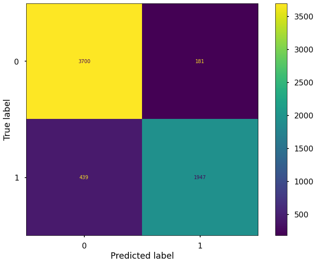

```python
confusion = metrics.confusion_matrix(y_train_pred_final.Converted, y_train_pred_final.Predicted )
disp = ConfusionMatrixDisplay(confusion_matrix=confusion)
disp.plot()
```

```python
TP = confusion[1,1] # true positive
TN = confusion[0,0] # true negatives
FP = confusion[0,1] # false positives
FN = confusion[1,0] # false negatives

sensitivity  = TP / float(TP+FN)
specificity = TN / float(TN+FP)
```

```python
print(classification_report(y_train_pred_final.Converted, y_train_pred_final.Predicted, labels=[0, 1]))
```

```
              precision    recall  f1-score   support

           0       0.89      0.95      0.92      3881
           1       0.91      0.82      0.86      2386

    accuracy                           0.90      6267
   macro avg       0.90      0.88      0.89      6267
weighted avg       0.90      0.90      0.90      6267
```

```python
# Let's check the overall accuracy.
print("Accuracy score :",metrics.accuracy_score(y_train_pred_final.Converted, y_train_pred_final.Predicted))
print("\n")
print("Precision score :",precision_score(y_train_pred_final.Converted, y_train_pred_final.Predicted))
print("\n")
print("sensitivity :",sensitivity)
print("\n")
print("specificity :",specificity)
```

```
Accuracy score : 0.9010690920695708


Precision score : 0.9149436090225563


sensitivity : 0.8160100586756077


specificity : 0.9533625354290132
```

After running the model on the Train Data these are the figures we obtain:

```
Accuracy : 90.00%
Sensitivity : 81.60%
Specificity : 95.33%
```

#### Predict using Test Data

```python
#scaling test set

num_cols=X_test.select_dtypes(include=['float64', 'int64']).columns

X_test[num_cols] = scaler.fit_transform(X_test[num_cols])

X_test = X_test[col]
X_test.head()
```

|  | Total Time Spent on Website | Lead Origin_Lead Add Form | Lead Source_Olark Chat | Lead Source_Welingak Website | Last Activity_Email Bounced | Last Activity_Olark Chat Conversation | Last Notable Activity_Modified | Tags_Interested in other courses | Tags_Lost to EINS | Tags_Other_Tags | Tags_Ringing | Tags_Will revert after reading the email |
| --- | --- | --- | --- | --- | --- | --- | --- | --- | --- | --- | --- | --- |
| 3253 | -0.269218 | 0 | 0 | 0 | 0 | 0 | 0 | 0 | 0 | 0 | 1 | 0 |
| 2715 | -0.625701 | 0 | 0 | 0 | 0 | 0 | 1 | 0 | 0 | 1 | 0 | 0 |
| 2069 | -0.876902 | 1 | 0 | 0 | 0 | 0 | 0 | 0 | 0 | 0 | 0 | 1 |
| 1752 | -0.876902 | 0 | 1 | 0 | 0 | 0 | 0 | 0 | 0 | 0 | 0 | 0 |
| 3001 | 2.161517 | 0 | 0 | 0 | 0 | 0 | 0 | 0 | 0 | 0 | 0 | 0 |

```python
X_test_sm = sm.add_constant(X_test)
```

```python
y_test_pred = res.predict(X_test_sm)
```

```python
y_test_pred
```

```
3253    0.012260
2715    0.006070
2069    0.998783
1752    0.355679
3001    0.838965
          ...
8730    0.952467
7340    0.990621
2630    0.998783
8704    0.638030
3034    0.999865
Length: 2686, dtype: float64
```

```python
# Convert predicted values into dataframe along with prospectId, Lead Score
y_test_pred_final = pd.DataFrame({'Converted':y_test.values, 'Converted_prob':y_test_pred.values.reshape(-1)})
y_test_pred_final['Prospect ID'] = y_test.index
y_test_pred_final['Lead_Score'] = y_test_pred_final.Converted_prob.map( lambda x: round(x*100))
y_test_pred_final.head()
```

|  | Converted | Converted_prob | Prospect ID | Lead_Score |
| --- | --- | --- | --- | --- |
| 0 | 0 | 0.012260 | 3253 | 1 |
| 1 | 0 | 0.006070 | 2715 | 1 |
| 2 | 1 | 0.998783 | 2069 | 100 |
| 3 | 1 | 0.355679 | 1752 | 36 |
| 4 | 1 | 0.838965 | 3001 | 84 |

```python
y_test_pred_final['final_Predicted'] = y_test_pred_final.Converted_prob.map(lambda x: 1 if x > 0.3 else 0)
y_test_pred_final.head()
```

|  | Converted | Converted_prob | Prospect ID | Lead_Score | final_Predicted |
| --- | --- | --- | --- | --- | --- |
| 0 | 0 | 0.012260 | 3253 | 1 | 0 |
| 1 | 0 | 0.006070 | 2715 | 1 | 0 |
| 2 | 1 | 0.998783 | 2069 | 100 | 1 |
| 3 | 1 | 0.355679 | 1752 | 36 | 1 |
| 4 | 1 | 0.838965 | 3001 | 84 | 1 |

```python
# Let's check the test accuracy.
print(metrics.accuracy_score(y_test_pred_final.Converted, y_test_pred_final.final_Predicted))
```

```
0.8916604616530156
```

```
<sklearn.metrics._plot.confusion_matrix.ConfusionMatrixDisplay at 0x23593669e50>
```

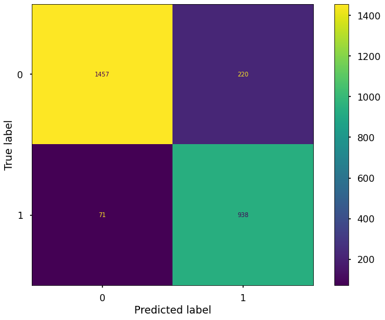

```python
confusion2 = metrics.confusion_matrix(y_test_pred_final.Converted, y_test_pred_final.final_Predicted )
disp = ConfusionMatrixDisplay(confusion_matrix=confusion2)
disp.plot()
```

```python
TP = confusion2[1,1] # true positive
TN = confusion2[0,0] # true negatives
FP = confusion2[0,1] # false positives
FN = confusion2[1,0] # false negatives
```

```python
sensitivity  = TP / float(TP+FN)
specificity = TN / float(TN+FP)
print("sensitivity :",sensitivity)
print("specificity :",specificity)
```

```
sensitivity : 0.929633300297324
specificity : 0.8688133571854502
```

```python
# classification report for the class 0 and 1
print(classification_report(y_test_pred_final.Converted, y_test_pred_final.final_Predicted, labels=[0, 1]))
```

```
              precision    recall  f1-score   support

           0       0.95      0.87      0.91      1677
           1       0.81      0.93      0.87      1009

    accuracy                           0.89      2686
   macro avg       0.88      0.90      0.89      2686
weighted avg       0.90      0.89      0.89      2686
```

```python
print("Precision score :",precision_score(y_test_pred_final.Converted, y_test_pred_final.final_Predicted))
print("\n")
print("Recall score :",recall_score(y_test_pred_final.Converted, y_test_pred_final.final_Predicted))
print("\n")
print("sensitivity :",sensitivity)
print("\n")
print("specificity :",specificity)
```

```
Precision score : 0.8100172711571675


Recall score : 0.929633300297324


sensitivity : 0.929633300297324


specificity : 0.8688133571854502
```

OBservation from the Model:

After running the model on the Test Data these are the figures we obtain:

```
Accuracy : 89.00%
Sensitivity : 92.96%
Specificity : 86.88%
```

After running the model on the Train Data these are the figures we obtain:

```
Accuracy : 90.00%
Sensitivity : 81.60%
Specificity : 95.33%
```

We should be able to offer the CEO confidence that decisions made with this model would be wise because it appears to forecast the Conversion Rate rather effectively.